# Introduction to rspeaksnonmem

Mike K Smith (Mike.K.Smith@Pfizer.com)

2017-04-12

## What does `rspeaksnonmem` do?

`rspeaksnonmem` is designed to allow the user to craft workflows based on a given NONMEM model. It is not intended to replace Perl speaks Nonmem (PsN) - in fact `rspeaksnonmem` can call and use PsN functionality from an R script. In fact `rspeaksnonmem` could equally be called “rspeaksPsN”. `rspeaksnonmem` helps the user by allow them to write complex workflows using NONMEM, PsN and R. For example performing data checkout (exploratory analysis), using a “template” model as a starting point for model refinement, specifying and running a sequence of tasks for every model, collating results across models for model comparison.

After importing and parsing a control stream to an R object using the `RNMImport` package, `rspeaksnonmem` allows the user to easily change initial estimates, change data attributes or change task properties (estimation or simulation settings) without having to change the model. This saves a lot of textual searching by the user.

To best use `rspeaksnonmem` it is useful to think of the NMTRAN expression of the model as a combination of: * Data specification * Parameter specification * Model specification (structural, covariate and stochastic components) * Task specification

With `rspeaksnonmem` it is easy to alter data, parameter and task information, but altering the model specification has knock-on effects across many other aspects. We recommend that the user sets up the model in such a way that it is easy to change the model simply by fixing or estimating certain parameters i.e. fixing population parameters and/or altering the OMEGA and SIGMA parameter specification.

Using a template model and a user-specified workflow function e.g. a function combining `execute_PsN` + `sumo_PsN` + `basic_GOF` the user could specify a number of combinations of THETA, OMEGA and SIGMA that would test a range of plausible models, run these models and then compare the output (OFV / AIC and model diagnostics) to find the best model fit. This is suggested not as a way of finding the best *final* model, but the best *base* model for further refinement. There is no substitute for the knowledge and skill of an analyst in building and assessing models. We refer the reader to Schmidt and Radivojevic (2014), JPKPD (http://www.ncbi.nlm.nih.gov/pubmed/25056507).

## Installation

### Dependencies

`rspeaksnonmem` relies on the package [`RNMImport`](https://github.com/MikeKSmith/RNMImport) function `importNmMod` which reads and parses the NONMEM control stream. `rspeaksnonmem` then works with the data, parameter values, and task information separately from the model.

Before installation of `rspeaksnonmem`, the package `RNMImport` needs to be installed.

Install RNMIMport from Github using the `devtools` package. `rspeaksnonmem` requires the version of RNMImport on MikeKSmith’s Github repository which includes handling of OMEGA and SIGMA blocks and identifying which elements are fixed for these parameters.

### Install rspeaksnonmem

Copy an example dataset and model to a directory of your choice

```r
getwd()
file.copy(from = file.path(system.file("exdata", package = "rspeaksnonmem"),
                           "warfarin_conc_pca.csv"),
            to = getwd(), overwrite = T )
file.copy(from = file.path(system.file("exdata", package = "rspeaksnonmem"),
                           "warfarin_bootstrap50.dta"),
            to = getwd(), overwrite = T )
file.copy(from = file.path(system.file("exdata", package = "rspeaksnonmem"),
                           "warfarin.ctl"),
            to = getwd(), overwrite = T )
```

The initial model within the workflow should act as a “template” for modifications. The best practice is to use a model where all possible parameters are defined (including OMEGAs and covariances / correlations) but where it is possible to fix parameters to zero or some null value. We can then run and test a wide variety of models simply by updating the $THETA, $OMEGA and $SIGMA parameters to allow estimation.

## Read the control stream using RNMImport

First, we need to read the NONMEM control stream into R using the `importNmMod` function of RNMImport.

```r
warfModel <- importNmMod("warfarin.ctl")
class(warfModel)
```

```
[1] "nmModel"
attr(,"package")
[1] "RNMImport"
```

```r
names(warfModel)
```

```
[1] "Raw"             "Comments"        "controlFile"     "problemContents"
```

This function reads NONMEM control streams and parses the code. The initial R object contains the raw code as a vector of character strings, any comments from the NONMEM code (anything after “;” in the NMTRAN), the name of the control file in `controlFile` and the parsed code within the list `problemContents`. RNMImport allows for cases where there is more than one NONMEM `$PROBLEM` statement within the code.

We can select the parsed control stream as the basis for modification. Here we take the first / only `$PROBLEM` statement content.

```r
warfTemplateModel <- warfModel$problemContents[[1]]
str(warfTemplateModel)
```

```
List of 12
 $ Theta     :'data.frame': 6 obs. of  5 variables:
  ..$ Lower   : num [1:6] 0.001 0.001 0.001 0.25 0 0
  ..$ Est     : num [1:6] 0.1 8 2 0.25 0.01 0.05
  ..$ Upper   : num [1:6] Inf Inf Inf 0.25 Inf ...
  ..$ FIX     : logi [1:6] FALSE FALSE FALSE TRUE FALSE FALSE
  ..$ comments: chr [1:6] "POP_CL" "POP_V" "POP_KA" "POP_TLAG" ...
 $ Omega     :List of 3
  ..$              :List of 5
  .. ..$ values  : num [1:2, 1:2] 0.1 0.01 0.01 0.1
  .. .. ..- attr(*, "dimnames")=List of 2
  .. .. .. ..$ : chr [1:2] "PPV_CL" "PPV_V"
  .. .. .. ..$ : chr [1:2] "PPV_CL" "PPV_V"
  .. ..$ block   : num 2
  .. ..$ FIX     : logi FALSE
  .. ..$ SAME    : logi FALSE
  .. ..$ comments: chr [1:3] "" "PPV_CL" "PPV_V"
  ..$              :'data.frame':   2 obs. of  3 variables:
  .. ..$ values  : num [1:2] 0.1 0
  .. ..$ FIX     : logi [1:2] FALSE TRUE
  .. ..$ comments: chr [1:2] "PPV_KA" "PPV_TLAG"
  ..$ initialMatrix: num [1:4, 1:4] 0.1 0.01 0 0 0.01 0.1 0 0 0 0 ...
  .. ..- attr(*, "dimnames")=List of 2
  .. .. ..$ : chr [1:2, 1:2] "PPV_CL" "PPV_V" "PPV_KA" "PPV_TLAG"
  .. .. ..$ : chr [1:2, 1:2] "PPV_CL" "PPV_V" "PPV_KA" "PPV_TLAG"
 $ Sigma     :List of 2
  ..$              :'data.frame':   1 obs. of  3 variables:
  .. ..$ values  : num 1
  .. ..$ FIX     : logi TRUE
  .. ..$ comments: logi NA
  ..$ initialMatrix: num [1, 1] 1
  .. ..- attr(*, "dimnames")=List of 2
  .. .. ..$ : chr "SIGMA1"
  .. .. ..$ : chr "SIGMA1"
 $ Problem   : chr "WARFARIN PK"
 $ Tables    :'data.frame': 4 obs. of  5 variables:
  ..$ File     : chr [1:4] "sdtab0" "patab0" "cotab0" "catab0"
  ..$ Columns  : chr [1:4] "ID, TIME, IPRED, IRES, RES, PRED, WRES" "ID, CL, V, KA, ALAG1, ETA.1., ETA.2., ETA.3., ETA.4." "ID, AGE, WT" "ID, SEX"
  ..$ NoHeader : logi [1:4] FALSE FALSE FALSE FALSE
  ..$ firstOnly: logi [1:4] FALSE FALSE FALSE FALSE
  ..$ append   : logi [1:4] TRUE FALSE FALSE FALSE
 $ Subroutine: chr [1:2] "ADVAN2" "TRANS2"
 $ Input     : chr [1:9, 1:2] "ID" "TIME" "WT" "AGE" ...
  ..- attr(*, "dimnames")=List of 2
  .. ..$ : chr [1:9] "1" "2" "3" "4" ...
  .. ..$ : chr [1:2] "nmName" "Label"
 $ Data      : chr [1, 1:8] "warfarin_conc_pca.csv" "#;(DVID.EQ.2)" "" "FALSE" ...
  ..- attr(*, "dimnames")=List of 2
  .. ..$ : NULL
  .. ..$ : chr [1:8] "File" "IG" "ACCEPT" "REWIND" ...
 $ PK        : chr [1:9] "GRPCL = THETA(1) *(WT/70) **0.75" "GRPV = THETA(2) *WT/70" "GRPKA = THETA(3) " "GRPLG = THETA(4) " ...
 $ Error     : chr [1:15] "(ONLY OBSERVATIONS) " "CENTRAL = F" "CC = (CENTRAL/V) " "IPRED = CC" ...
 $ Estimates : chr "METHOD=COND INTER MAX=9990 SIG=3 NOABORT"
 $ Cov       : chr(0)
```

Now with the parsed content, it is much easier to change elements within the NONMEM control stream since we’re only manipulating text strings. But since the code has been parsed it’s more transparent to a third party exactly what is being changed.

First let’s change the dataset. Here I’ve sampled 50 subjects from the original warfarin dataset (warfarin.csv) into a dataset called “warfarin_bootstrap50.dta”. Since the names and uses of the data columns is unchanged, we do not need to change anything in the `$INPUT statement` of NMTRAN. So we create a new object called `newData` containing the original code, then update the file name.

```r
newData <- warfModel$problemContents[[1]]$Data
newData[,"File"] <- "warfarin_bootstrap50.dta"
```

In a similar way, we can then update any element of the model using this parsed set of commands. `rspeaksnonmem` provides some additional functions to extract certain elements of the parsed control stream.

| “Object” | `rspeaksnonmem` Function | NMTRAN blocks |
| --- | --- | --- |
| Data | getNMDataObjects | `$DATA`, `$INPUT` |
| Parameter | getNMParameterObjects | `$THETA`, `$OMEGA`, `$SIGMA` |
| Task | getNMTaskPropertiesObjects | `$EST`,`$COV`, `$TAB` |
| Model | getNMModelObjects | everything else |

For example: `getNMParameterObjects` returns the $THETA, $OMEGA and $SIGMA records. Since the `$THETA`parameters are represented as a data frame, we can easily update the initial values, lower or upper bounds, fix or estimate (unfix)`THETA`parameters. With each object returned by the various`getNM<…>` functions we get not only the parsed objects but the raw control stream as well.

```r
params <- getNMParameterObjects(warfModel)
str(params)
```

```
List of 4
 $ RAW  : chr [1:15] "$THETA" "(0.001, 0.1, ) ; POP_CL" "(0.001, 8, ) ; POP_V" "(0.001, 2, ) ; POP_KA" ...
 $ THETA:'data.frame':  6 obs. of  5 variables:
  ..$ Lower   : num [1:6] 0.001 0.001 0.001 0.25 0 0
  ..$ Est     : num [1:6] 0.1 8 2 0.25 0.01 0.05
  ..$ Upper   : num [1:6] Inf Inf Inf 0.25 Inf ...
  ..$ FIX     : logi [1:6] FALSE FALSE FALSE TRUE FALSE FALSE
  ..$ comments: chr [1:6] "POP_CL" "POP_V" "POP_KA" "POP_TLAG" ...
 $ OMEGA:List of 3
  ..$              :List of 5
  .. ..$ values  : num [1:2, 1:2] 0.1 0.01 0.01 0.1
  .. .. ..- attr(*, "dimnames")=List of 2
  .. .. .. ..$ : chr [1:2] "PPV_CL" "PPV_V"
  .. .. .. ..$ : chr [1:2] "PPV_CL" "PPV_V"
  .. ..$ block   : num 2
  .. ..$ FIX     : logi FALSE
  .. ..$ SAME    : logi FALSE
  .. ..$ comments: chr [1:3] "" "PPV_CL" "PPV_V"
  ..$              :'data.frame':   2 obs. of  3 variables:
  .. ..$ values  : num [1:2] 0.1 0
  .. ..$ FIX     : logi [1:2] FALSE TRUE
  .. ..$ comments: chr [1:2] "PPV_KA" "PPV_TLAG"
  ..$ initialMatrix: num [1:4, 1:4] 0.1 0.01 0 0 0.01 0.1 0 0 0 0 ...
  .. ..- attr(*, "dimnames")=List of 2
  .. .. ..$ : chr [1:2, 1:2] "PPV_CL" "PPV_V" "PPV_KA" "PPV_TLAG"
  .. .. ..$ : chr [1:2, 1:2] "PPV_CL" "PPV_V" "PPV_KA" "PPV_TLAG"
 $ SIGMA:List of 2
  ..$              :'data.frame':   1 obs. of  3 variables:
  .. ..$ values  : num 1
  .. ..$ FIX     : logi TRUE
  .. ..$ comments: logi NA
  ..$ initialMatrix: num [1, 1] 1
  .. ..- attr(*, "dimnames")=List of 2
  .. .. ..$ : chr "SIGMA1"
  .. .. ..$ : chr "SIGMA1"
```

Together the Data, Parameters, Model and Task “objects” form a “Modelling Object Group” or MOG which is used for a specific estimation task.

We can create multiple “objects” corresponding to different models that we wish to explore. So below we create an object called thetaNoLag where the `$THETA` for the LAG term is fixed to zero. We also create an object called “thetaLag” where we set `FIX = FALSE` and give a reasonable initial value for the Lag.

```r
FIX_POP_TLAG <- list(Lower = 0, Est = 0, Upper = 0, FIX = TRUE, comments = "POP_TLAG")
EST_POP_TLAG <- list(Lower = 0, Est = 0.75, Upper = 1.5, FIX = FALSE, comments = "POP_TLAG")
thetaNoLag <- warfTemplateModel$Theta
thetaNoLag["POP_TLAG",] <- FIX_POP_TLAG
thetaLag <- warfTemplateModel$Theta
thetaLag["POP_TLAG",] <- EST_POP_TLAG
```

The template model has a combined proportional and additive residual error structure. This has been parameterised as `W = THETA(5)+THETA(6)*CONC` in the NMTRAN code. W then multiplies a standard Normal variate to give the residual error: `W * SIGMA` where SIGMA ~ N(0,1).

To be able to estimate different residual error models, we can then simply fix one or other component of the residual error model. Fixing `THETA(5)` to zero will estimate with only proportional error, while fixing `THETA(6)` to zero will estimate with only additive error. Estimating both provides the combined additive and proportional residual error.

```r
ruvPropOnly <- list(Est = 0, FIX = TRUE, comments = "RUV_ADD")
```

Again, in a similar way we can update the between subject `OMEGA` parameter specification to examine a variety of models - where Clearance (CL) and Volume of Distribution (V) are independent / uncorrelated, or where they are correlated. We can also easily fix or estimate between subject variability on parameters such as KA by specifying initial values and ensuring `FIX = FALSE`.

The template model specifies an OMEGA block (covariance) between ETA_CL and ETA_V.

```r
CLVBlock_noTLAG <- params$OMEGA
diagPPV_noTLAG <- list(data.frame(values=c(0.1,0.1,0.1),
                            FIX=c(F,F,F),
                            comments=c("; PPV_CL", "; PPV_V", "; PPV_KA")),
                       list(values = 0, FIX = TRUE))
```

Bringing all of these different components together, we can examine the fit of a number of basic models, starting only with the template model. We use the `updateModel` function to update the template model with objects that we have defined or altered.

```r
  run1 <- updateModel(warfTemplateModel,
                      theta = thetaNoLag,
                      omega = diagPPV_noTLAG,
                      data = newData,
                      runno = 1) ## First model
  run2 <- updateModel(warfTemplateModel,
                      theta = thetaLag,
                      omega = diagPPV_noTLAG ,
                      data = newData,
                      runno = 2)  ## Add POP_TLAG
  run3 <- updateModel(warfTemplateModel,
                      theta = thetaLag,
                      omega = CLVBlock_noTLAG,
                      data = newData,
                      runno = 3)  ## Change to block CL, V
```

`rspeaksnonmem` provides function that enable us to run NONMEM or PsN without leaving R. By combining these, we can define a sequence of steps that we may wish to perform in a script, or define a function that combines workflow steps that we would wish to perform **on each model**.

```r
myPopPKWorkflow <- function(model){
  controlFile <- paste(deparse(substitute(model)),".ctl",sep = "")
  lstFile <- paste(deparse(substitute(model)),".lst",sep = "")

  workingDir <- deparse(substitute(model))

  writeNMControlStream(templateModel = warfModel$Raw,
                       parsedControl = model,
                       outputFile = controlFile)
 execute_PsN(installPath = "c:/strawberry/perl",
              version = "4.6.0",
              modelFile = controlFile,
              lstFile = lstFile,
              clean = 1,
              working.dir = workingDir)

  sumo_PsN(tool = "sumo-3.5.4",
           installPath = "c:/strawberry/perl",
           version = "4.6.0",
           lstFile = lstFile)
  runno <- as.numeric(gsub("[a-z]", "", deparse(substitute(model))))

  ## ----createXpdb----------------------------------------------------------
  xpdb <- xpose4::xpose.data(runno = runno, quiet = T)
  # save(base.xpdb, file='Xpose database.RData')

  ## ----xposeGOF------------------------------------------------------------
  print(xpose4::dv.vs.pred.ipred(xpdb))
  print(xpose4::pred.vs.idv(xpdb))
  print(xpose4::ipred.vs.idv(xpdb))
  print(xpose4::wres.vs.idv(xpdb))
  print(xpose4::wres.vs.pred(xpdb))
  print(xpose4::ranpar.hist(xpdb))
  print(xpose4::ind.plots(xpdb, layout = c(4, 4)))
}
```

We can then run the workflow for each model in turn or “apply” the function across a list of models to be evaluated.

```
c:/strawberry/perl/bin/perl c:/strawberry/perl/bin/execute-4.6.0.pl   "run1.ctl" -directory="run1"
Starting 1 NONMEM executions. 1 in parallel.
S:1 ..
All executions started.
doing nmtran
        1 file(s) copied.
recompiling certain components.
starting wait
ending wait
Exiting lpreddo
Finished compiling fsubs
Completed call to gfcompile.bat
Starting nonmem execution ...
F:1 ..
Running PsN_execute_plots.R...

execute done
c:/strawberry/perl/bin/perl c:/strawberry/perl/bin/sumo-4.6.0.pl   "run1.lst"
-----------------------------------------------------------------------

run1.lst

Successful minimization                                           [    OK   ]
No rounding errors                                                [    OK   ]
No zero gradients                                                 [    OK   ]
No final zero gradients                                           [    OK   ]
Hessian not reset                                                 [    OK   ]
No parameter near boundary                                        [    OK   ]
Covariance step                                                   [    OK   ]
Large relative standard errors found                              [ WARNING ]
    __                     0.51334
Correlations                                                      [    OK   ]

Total run time for model (hours:min:sec):                  0:01:00
Estimation time for subproblem, sum over $EST (seconds):   3.4
Covariance time for subproblem, sum over $EST (seconds):   1.08

Objective function value: 491.7467

ETA shrinkage: 3.7591E+00 1.5037E+01 5.1199E+01 1.0000E+02
Number of observation records: 355
Number of individuals: 50

            THETA                   OMEGA              SIGMA
  POP_CL  0.04871  (0.04967)       0.3294  (0.1456)
   POP_V    2.791  (0.01495)   _  0.09258  (0.1158)
  POP_KA   0.3984    (0.252)  __   0.7012  (0.2567)
 RUV_ADD   0.5357   (0.1387)
RUV_PROP   0.0568    (0.265)

The relative standard errors for omega and sigma are reported on the approximate
standard deviation scale (SE/variance estimate)/2.
-----------------------------------------------------------------------

Looking for NONMEM table files.
    Reading sdtab1
    Reading patab1
    Reading catab1
    Reading cotab1
```

[output not shown]

```
Table files read.
    Reading run1.phi

Looking for NONMEM simulation table files.
No simulated table files read.
```

[output not shown]

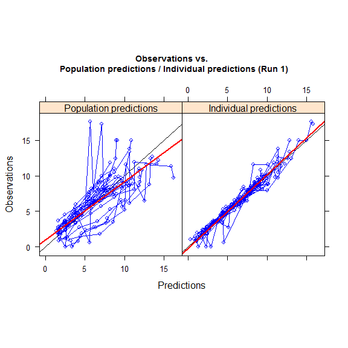

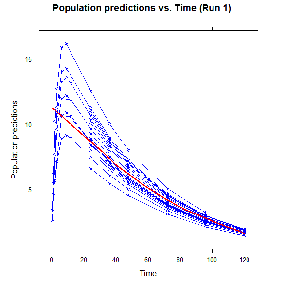

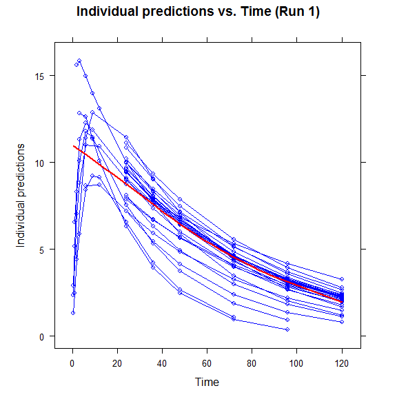

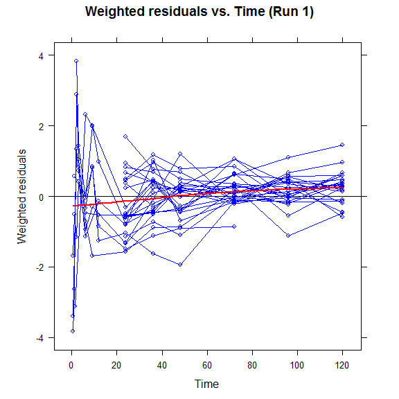

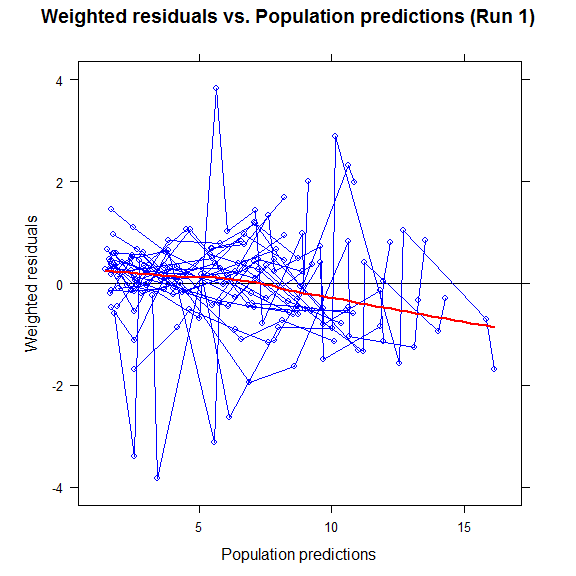

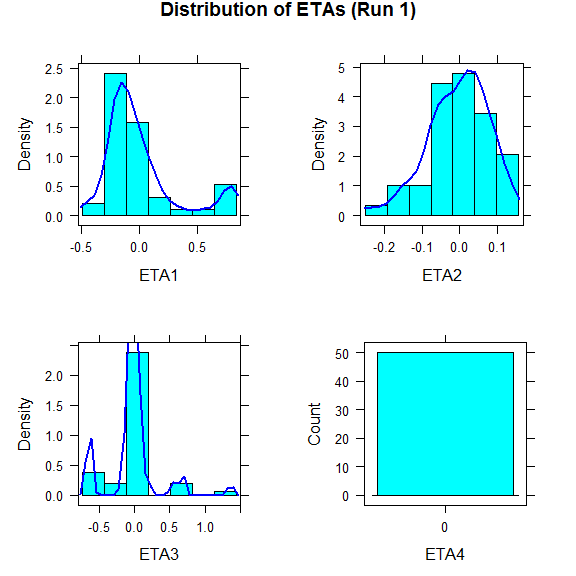

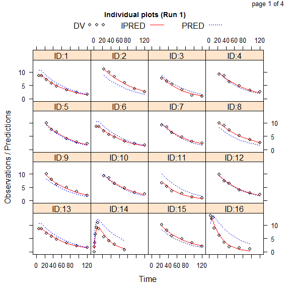

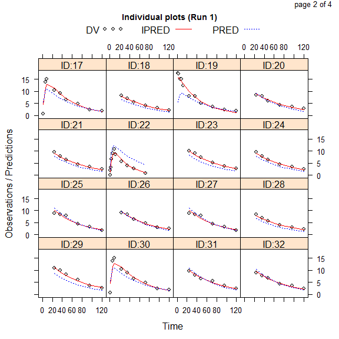

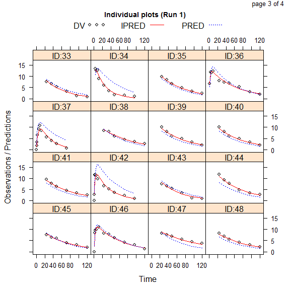

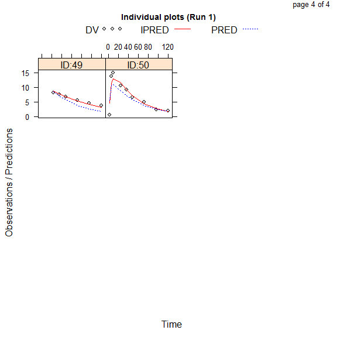

```r
myPopPKWorkflow(run1)
```

```
c:/strawberry/perl/bin/perl c:/strawberry/perl/bin/execute-4.6.0.pl   "run2.ctl" -directory="run2"
Starting 1 NONMEM executions. 1 in parallel.
S:1 ..
All executions started.
doing nmtran
        1 file(s) copied.
recompiling certain components.
starting wait
ending wait
Exiting lpreddo
Finished compiling fsubs
Completed call to gfcompile.bat
Starting nonmem execution ...
F:1 ..
Running PsN_execute_plots.R...

execute done
c:/strawberry/perl/bin/perl c:/strawberry/perl/bin/sumo-4.6.0.pl   "run2.lst"
-----------------------------------------------------------------------

run2.lst

Successful minimization                                           [    OK   ]
No rounding errors                                                [    OK   ]
Zero gradients found 1 times                                      [ WARNING ]
Final zero gradients                                              [  ERROR  ]
Hessian not reset                                                 [    OK   ]
Parameter(s) / ETA-/EPS-correlation(s) near boundary              [ WARNING ]
    RUV_ADD                 0.0001            0
Covariance step                                                   [  ERROR  ]



Total run time for model (hours:min:sec):                  00:00:00
Estimation time for subproblem, sum over $EST (seconds):   1.89

Objective function value: 331.8098

Number of observation records: 355
Number of individuals: 50

            THETA                    OMEGA                SIGMA
  POP_CL  0.04767  (........)       0.3141  (........)
   POP_V    2.828  (........)   _  0.08934  (........)
  POP_KA   0.6365  (........)  __   0.7896  (........)
POP_TLAG     0.54  (........)
 RUV_ADD   0.0001  (........)
RUV_PROP   0.1492  (........)

The relative standard errors for omega and sigma are reported on the approximate
standard deviation scale (SE/variance estimate)/2.
-----------------------------------------------------------------------

Looking for NONMEM table files.
    Reading sdtab2
    Reading patab2
    Reading catab2
    Reading cotab2
```

[output not shown]

```
Table files read.
    Reading run2.phi

Looking for NONMEM simulation table files.
No simulated table files read.
```

[output not shown]

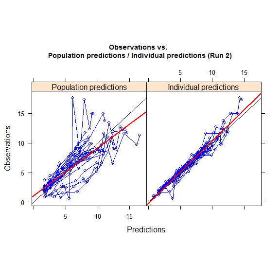

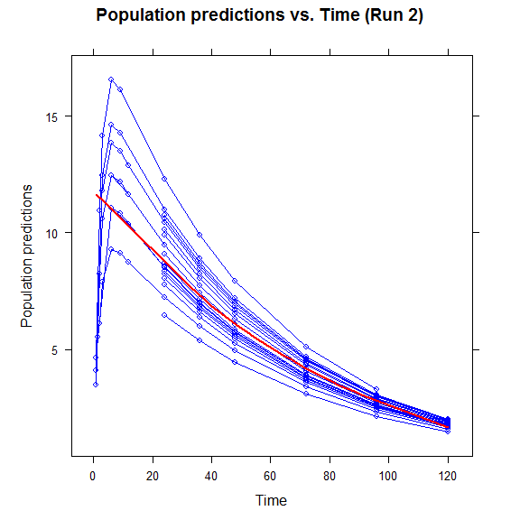

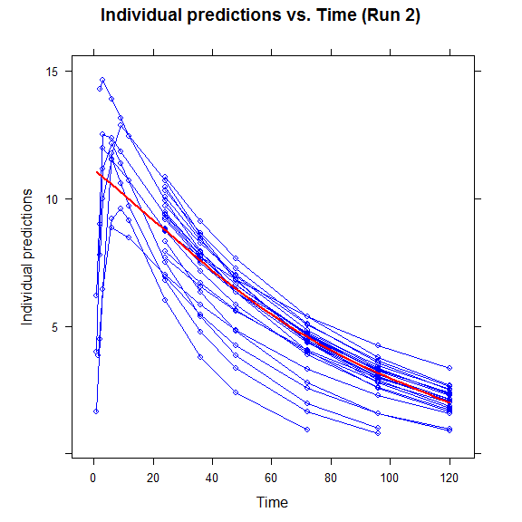

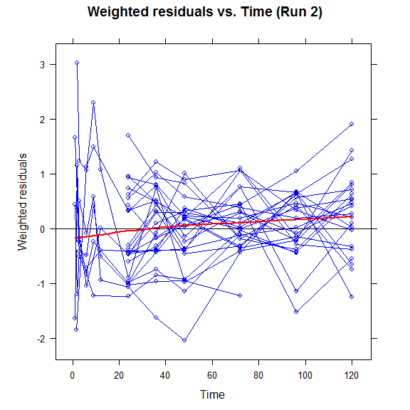

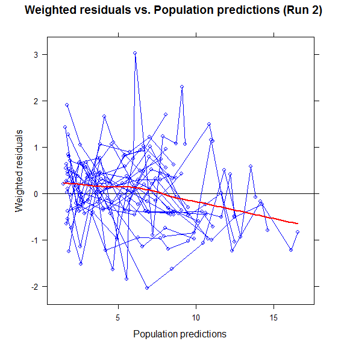

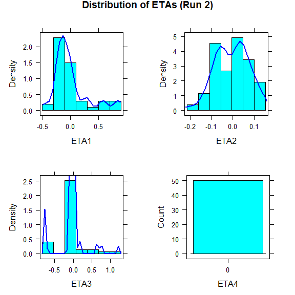

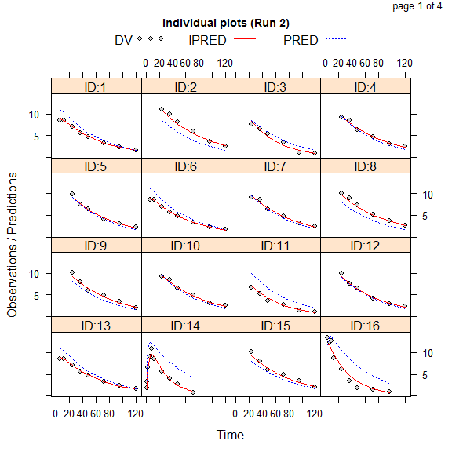

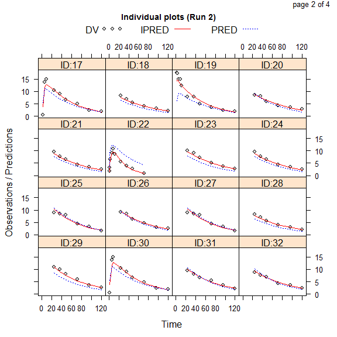

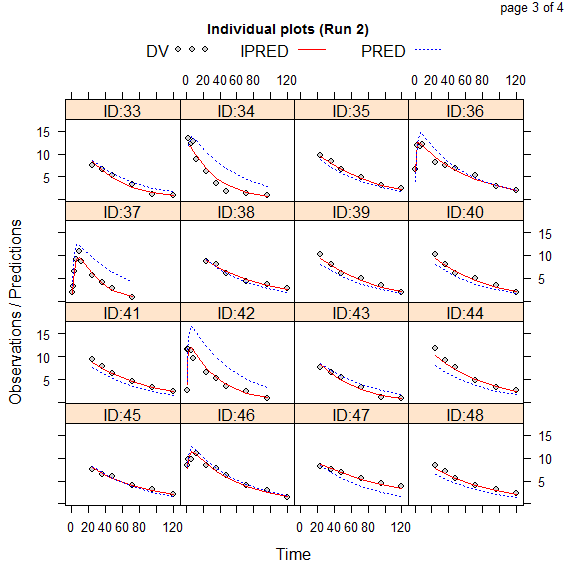

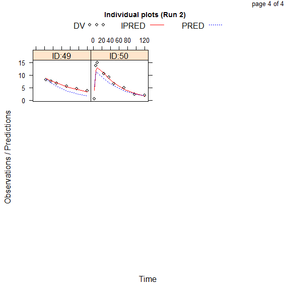

```r
myPopPKWorkflow(run2)
```

```
c:/strawberry/perl/bin/perl c:/strawberry/perl/bin/execute-4.6.0.pl   "run3.ctl" -directory="run3"
Starting 1 NONMEM executions. 1 in parallel.
S:1 ..
All executions started.
doing nmtran
        1 file(s) copied.
recompiling certain components.
starting wait
ending wait
Exiting lpreddo
Finished compiling fsubs
Completed call to gfcompile.bat
Starting nonmem execution ...
F:1 ..
Running PsN_execute_plots.R...

execute done
c:/strawberry/perl/bin/perl c:/strawberry/perl/bin/sumo-4.6.0.pl   "run3.lst"
-----------------------------------------------------------------------

run3.lst

Successful minimization                                           [    OK   ]
No rounding errors                                                [    OK   ]
Zero gradients found 1 times                                      [ WARNING ]
Final zero gradients                                              [  ERROR  ]
Hessian not reset                                                 [    OK   ]
Parameter(s) / ETA-/EPS-correlation(s) near boundary              [ WARNING ]
    RUV_ADD                 0.0001            0
Covariance step                                                   [  ERROR  ]



Total run time for model (hours:min:sec):                  00:00:00
Estimation time for subproblem, sum over $EST (seconds):   1.98

Objective function value: 328.9877

Number of observation records: 355
Number of individuals: 50

            THETA                            OMEGA                SIGMA
  POP_CL  0.04776  (........)      PPV_CL   0.3092  (........)
   POP_V    2.824  (........)  OMEGA(2,1)   0.2912  (........)
  POP_KA   0.6681  (........)       PPV_V  0.08785  (........)
POP_TLAG   0.5551  (........)      PPV_KA   0.7776  (........)
 RUV_ADD   0.0001  (........)
RUV_PROP   0.1496  (........)

The relative standard errors for omega and sigma are reported on the approximate
standard deviation scale (SE/variance estimate)/2.
-----------------------------------------------------------------------

Looking for NONMEM table files.
    Reading sdtab3
    Reading patab3
    Reading catab3
    Reading cotab3
```

[output not shown]

```
Table files read.
    Reading run3.phi

Looking for NONMEM simulation table files.
No simulated table files read.
```

[output not shown]

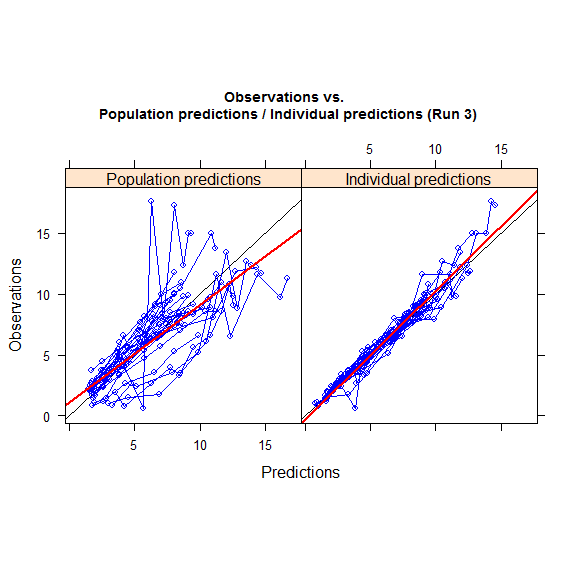

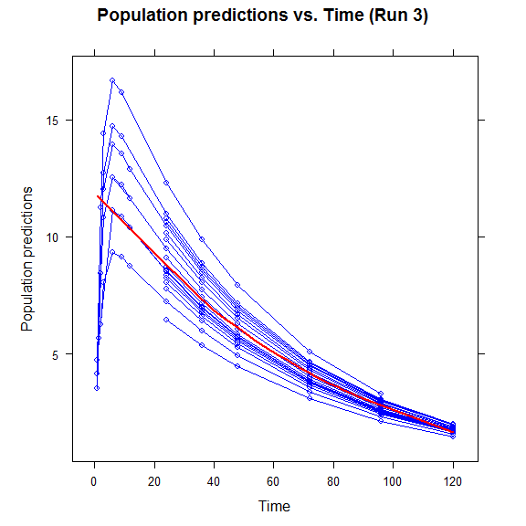

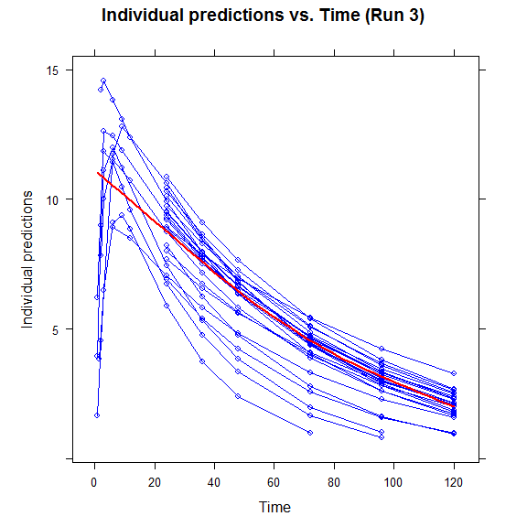

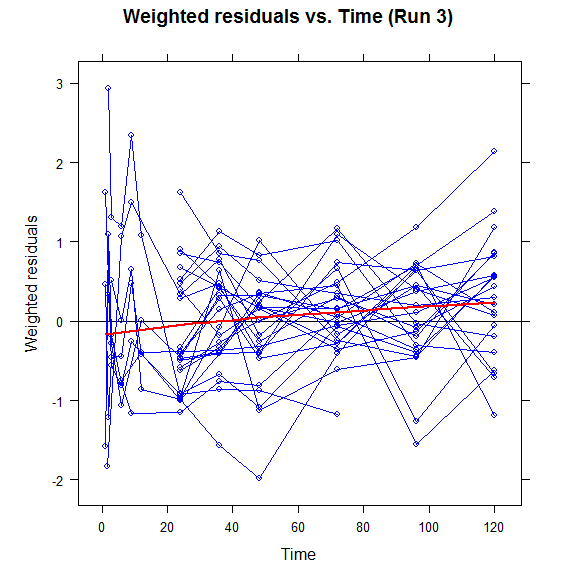

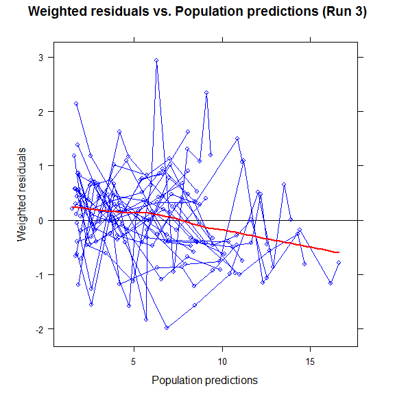

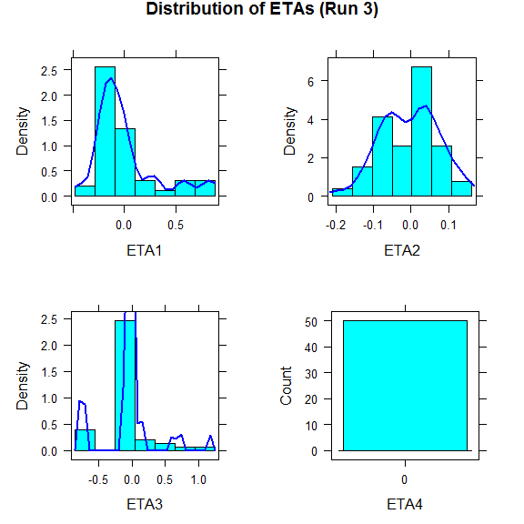

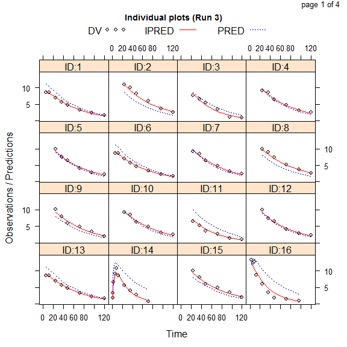

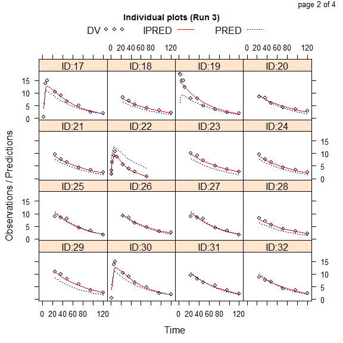

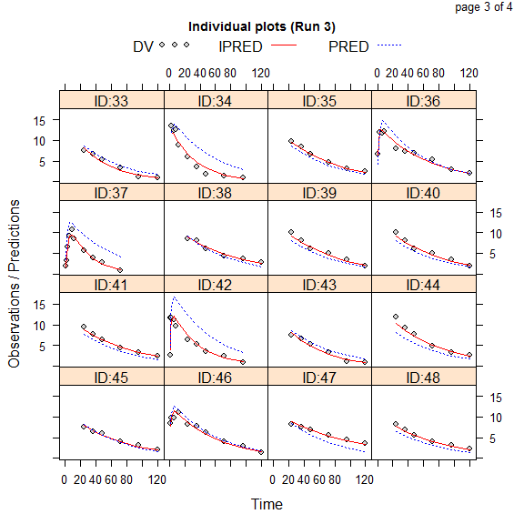

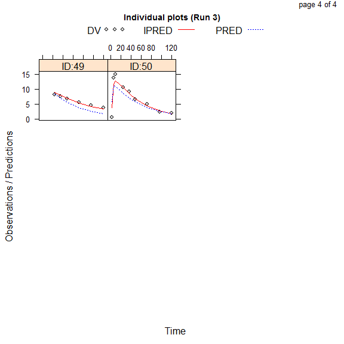

```r
myPopPKWorkflow(run3)
```